# ECE 474: Default Latex MidTerm template

Prof. Blake Hannaford  
Department of Electrical Engineering  
The University of Washington

16-May-25

## Rules

- Individual Work
- Closed Book, Closed Notes
- One-page (**two** sided) crib sheet allowed.
- 50 minutes
- 60 points

_______________________________________________________________________________________________________  
`NAME`

# Bode Magnitude and Phase Plot (14 Points)

Plot the Bode Magnitude plot (top) and Phase plot (bottom) on the axes below for
$$G_1(s) = \frac {2(s+100)(s+500)} {(s+1)(s+3100)^2}$$
Points breakdown:

| Straight line asymptotes = 3 pts. | Accurate magnitudes = 2 pts. |
| --- | --- |
| $\pm3dB$ etc. corrections = 3 pts. | Smooth mag. curve= 2 pts. |
| Smooth phase curve = 2 pts. | Correct axis labels = 2 pts. |

**SOLUTION:**  
Cartoon:

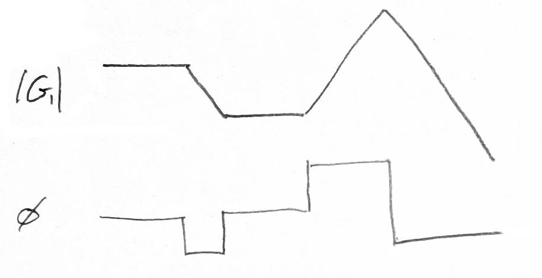

Bode Plot with smoothing corrections

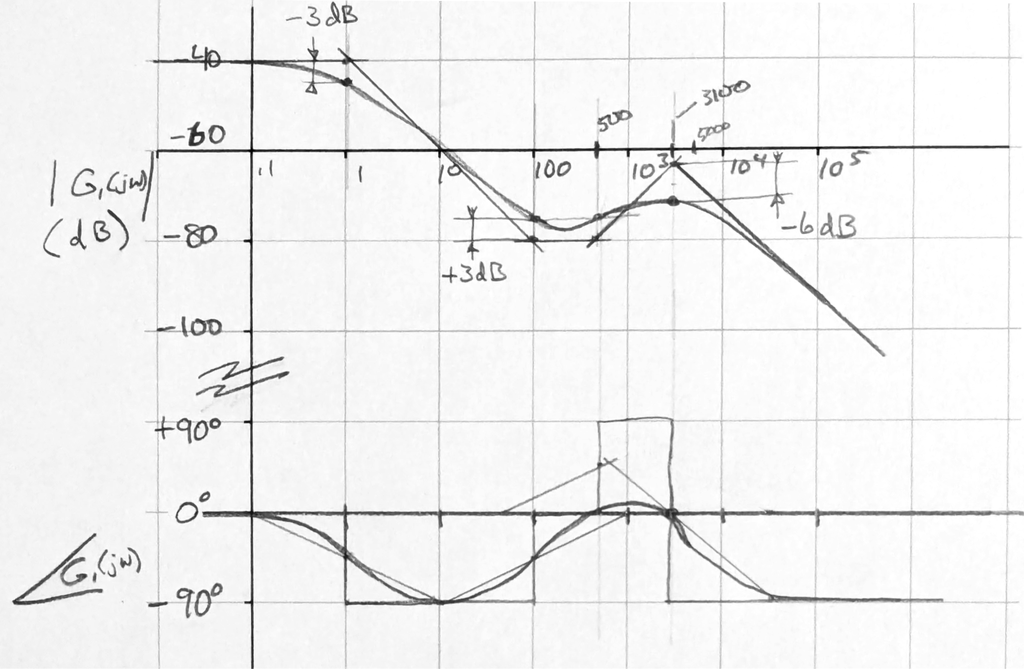

# Sensitivity Analysis with Closed Loop Control (11 points)

We are designing a controller for an expensive production machine (Plant). Our measure of performance ($P_i$) will be
$$P_i = \left | \frac {Y(s)} {X(s)} \right |_{\omega=10}$$

Unfortunately, our plant can vary in its key parameter, $\alpha$, by about 10%. We can safely assume that $K_P = 15$. Your task is to compute $S_{ij}$. In words, compute the sensitivity of $\left | \frac {Y(s)} {X(s)} \right |$ when $s=j10$ with respect to the parameter $\alpha$. When computing $\left | \frac {Y(s)} {X(s)} \right |$, do not convert it to $dB$.

Hint: first solve for the closed loop transfer function, $\frac {Y(s)} {X(s)}$ using H.S. Black’s equation
$$\frac {Y(s)} {X(s)} = \frac {CP} {1+CPH}$$

## 7 pts.

Assume that $K_C$ = 10, $\alpha=15$, $K_P=15$ and compute the sensitivity coefficient, $S_{ij}$, of gain magnitude at $\omega=10$ to the parameter $\alpha$ (as in ICPs, use a 10% difference).

**SOLUTION:**
$$\frac {Y(s)} {X(s)} = \frac {K_CK_P} {(s-\alpha)+K_CK_P} = \frac {K_CK_P} {s+K_CK_P-\alpha}$$
For $K_C=10$:
$$\mathrm{For: }\;\alpha = -15\; \mathrm{we~get }\; \left | \frac {150} {s+15+150} \right |_{s=j10} = \left | \frac {150} {165+10j} \right | = 0.9074$$
$$\mathrm{For: }\;\alpha = -15\times 1.10= -16.5\;\mathrm{we~get }\; \left | \frac {150}{s+16.5+150} \right |_{s=j10} =\left | \frac {150} {166.5+10j} \right | = 0.8993$$

|  | $\alpha$ | magnitude |
| --- | --- | --- |
|  | -15 | 0.9074 |
|  | -16.5 | 0.8993 |
| $\Delta$ | -1.5 | -0.0081 |

$$S_{ij} = \frac {-0.0081} {-1.5} \times \frac {15} {0.9074} = 8.9\%$$

## 4 pts.

Repeat the above computation for $K_C=100$, explain the significance of the result, if any, for designing your controller.

[output not shown]

# Disturbance Rejection (17 points)

## 8 pts

Find $K$ so that the disturbance response, $\frac{Y(s)}{D(s)}= -30dB$ for $\omega < 10.0$.

# `Solution`

$$\frac{Y(s)}{D(s)} = \frac {P} {1+CPH} = \frac {\frac{10}{(s+100)}} {1+\frac{10K}{(s+100)^2}}$$
$$= \frac {10(s+100)} {(s+100)^2+10K} = \frac {10(s+100)} {s^2+200s+10^4+10K}$$
for $\omega << 100$,
$$\left | \frac {Y(s)} {D(s)} \right | = \frac {10^3} {10^4+10K} = -30dB = \frac {1}{31.6}$$
$$10^3 = (10^4+10K)/31.6 \to 31600.0 = 10^4+10K \to 21600 = 10K$$
$$K = 2160$$

## 5 pts

Draw a Bode Magnitude Plot (no phase plot) of your solution to 3.1.

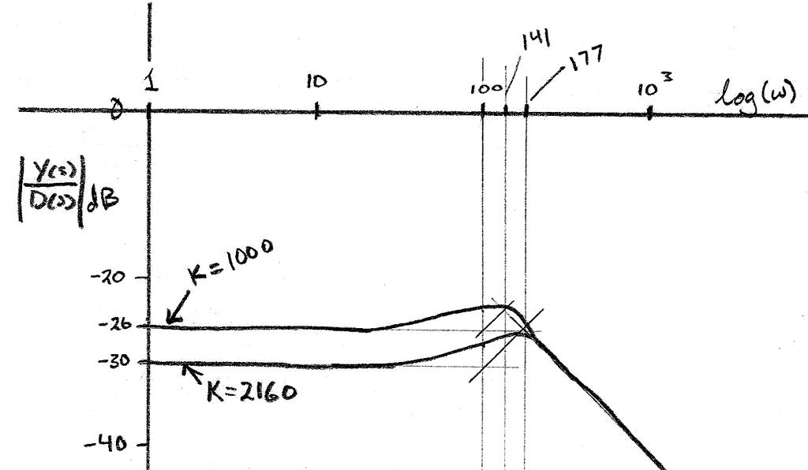

## 4 pts

Make another Bode Magnitude Plot on the same axes as 3.2 to show that $K=1000$ does **NOT** satisfy the goal of Problem 3.1.

# `Solution`

for $K=1000$,
$$\frac {Y} {D} = \frac {10(s+100)} {s^2+200s+10^4+10^4}$$
for $\omega << 100$,
$$\left | \frac {Y(s)} {D(s)} \right | = \frac {1000} {2\times10^4} = 0.05 = -26dB$$
$$\omega_n = \sqrt{2\times10^4} = 1.414\times10^2 = 141$$

**See 3.2 for Bode Plot.**

When $K=1000$, the disturbance response is only -26$dB$ so it is not enough. Note that for frequencies $>> 100$rad/sec, in both cases, the Plant acts like a low pass filter on the disturbance.

# Stability (18 points)

## (7 pts.)

Find the closed loop transfer function. As in past problems, your transfer function should be the ratio of two normalized polynomials.

**SOLUTION:**
$$\frac {Y(s)} {X(s)} = \frac {CP} {1+CPH} = \frac {G} {1+GH} = \frac {\frac {4000K} {(s+1)(s^2+320s+4\times10^4)}} {1+\frac {4000K} {(s+1)(s^2+320s+4\times10^4)}}$$
$$= \frac {4000K} {(s+1)(s^2+320s+4\times10^4) + 4000K}$$
$$\frac {Y(s)} {X(s)} = \frac {4000K} {s^3+321s^2+40320s+4\times10^4+4000K}$$

## (4 pts.)

With python we computed the poles of $\frac {Y(s)} {X(s)}$ for several values of $K$ as follows

```
K:    500.0 [  -133+0j   -94+81j   -94-81j ]
K:   1000.0 [  -221+0j  -50+126j  -50-126j ]
K:   1500.0 [  -256+0j  -33+150j  -33-150j ]
K:   2000.0 [  -280+0j  -21+168j  -21-168j ]
K:   2500.0 [  -299+0j  -11+183j  -11-183j ]
K:   3000.0 [  -315+0j   -3+196j   -3-196j ]
K:   3500.0 [  -328+0j    4+207j    4-207j ]
K:   4000.0 [  -341+0j   10+217j   10-217j ]
K:   4500.0 [  -352+0j   16+226j   16-226j ]
K:   5000.0 [  -362+0j   21+234j   21-234j ]
K:   5500.0 [  -372+0j   25+242j   25-242j ]
K:   6000.0 [  -381+0j   30+249j   30-249j ]
K:   6500.0 [  -389+0j   34+256j   34-256j ]
K:   7000.0 [  -397+0j   38+263j   38-263j ]
K:   7500.0 [  -405+0j   42+269j   42-269j ]
K:   8000.0 [  -412+0j   45+275j   45-275j ]
K:   8500.0 [  -419+0j   49+281j   49-281j ]
K:   9000.0 [  -425+0j   52+286j   52-286j ]
K:   9500.0 [  -432+0j   55+292j   55-292j ]
```

Approximately what value of $K$ is the upper limit where instability will occur?

**SOLUTION:**
There are three poles since the denominator of the CLTF since it is 3rd order. There is one real pole (listed first by python) and two CC poles (e.g.$-94\pm81j$ at $K=500$). The real part of the CC poles turns positive between $K=3000$ and $K=3500$. Since the real part is kind of symmetrical about zero ($-3, +4$) we can split the difference:
$$K_{limit} \approx 3250$$

## (7 pts.)

A different control system was tested in a lab, producing the following Bode Plots for the loop gain: $CPH(s)$:

**SOLUTION:**

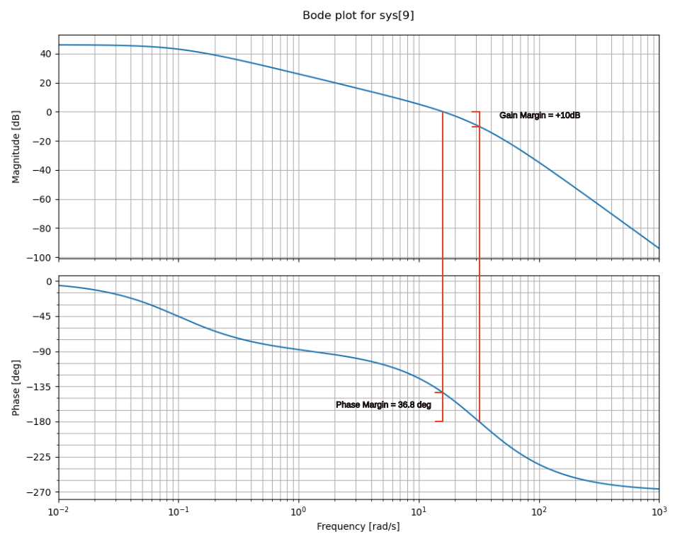

Draw a vertical line on the plot and indicate the Gain Margin in $dB$. (and give the value of Gain Margin)

Draw another vertical line on the plot and indicate the Phase Margin in $dB$. (and give the value of Phase Margin)

See above plot.

According to these Margins, is the system stable or unstable?

Gain margins are $+10.3dB$ and $36.8^\circ$. Since they are both positive the system is stable.